# Final Project

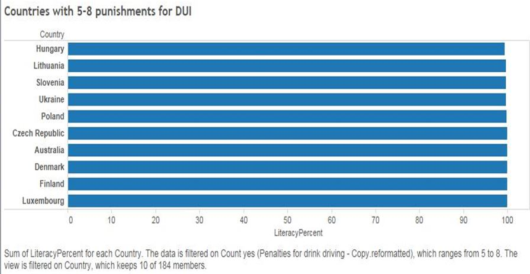

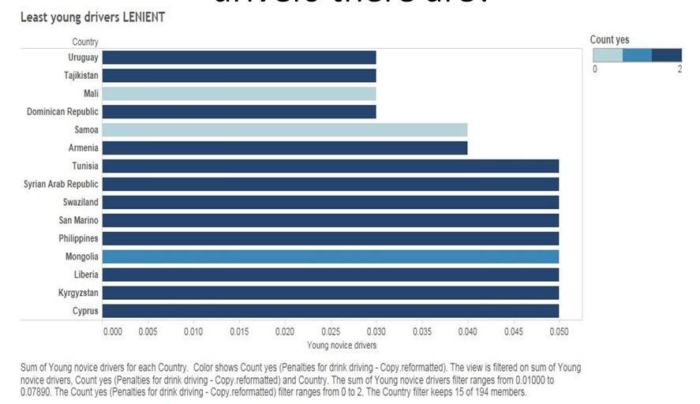

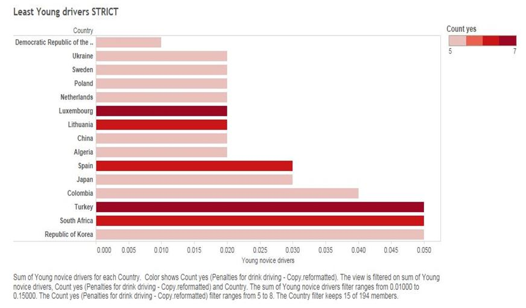

These countries have a low percent of young drivers, regardless they employ a high if not all amount of punishments for being caught driving under the influence

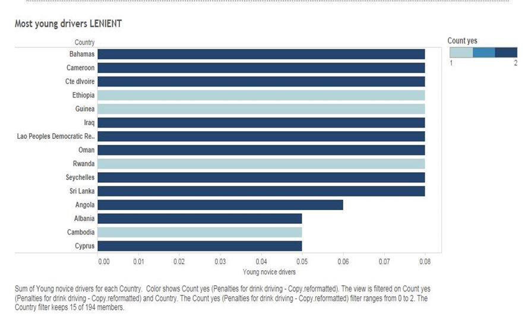

I thought maybe that having a high percent of young drivers a country would be more strict in the amount of punishments for a DUI. Our data did not support this however. Even though these countries had a lot of young drivers on the streets it did not affect the amount of punishments they’d administer.

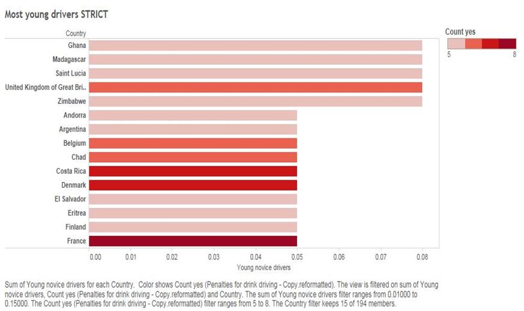

These countries have the most amount of young drivers and take drunk driving very seriously employing many different punishments for drunk driving